## Практична робота №1 . Елементи комбінаторики. Класичне визначення ймовірності.Застосування комбінаторики для розрахунку ймовірностей.

# Мета : набути практичних навичок у розв’язанні задач з комбінаторики.

# 1 . Скільки різних чисел можливо отримати, переставляючи числа 2 233 344 455?

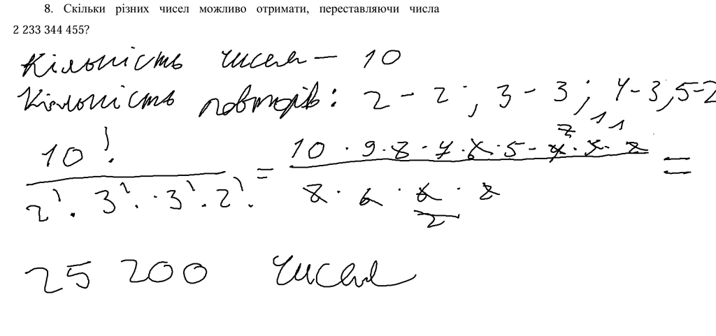

# 2 . 9*. (Задача Д. Ільченко). Є 1000 доменів, на кожному з яких повинен бути набір з 6-ти блоків контенту, кожен набір повинен відрізнятися 2-ма блоками від будь-якого іншого. Скільки необхідно всього унікальних блоків, щоб задовольнити такій умові?

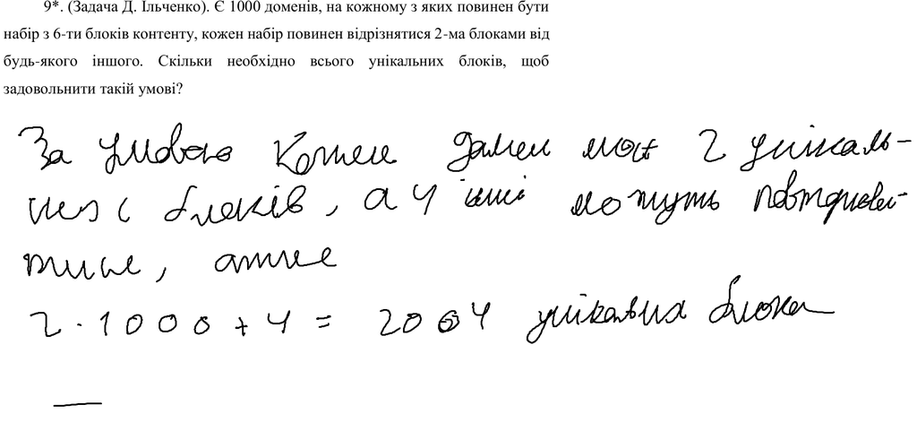

# 3 . У пасажирському потязі 9 вагонів. Скількома способами можливо розсадити в потязі 4 людей за умови, що всі вони повинні їхати в різних вагонах?

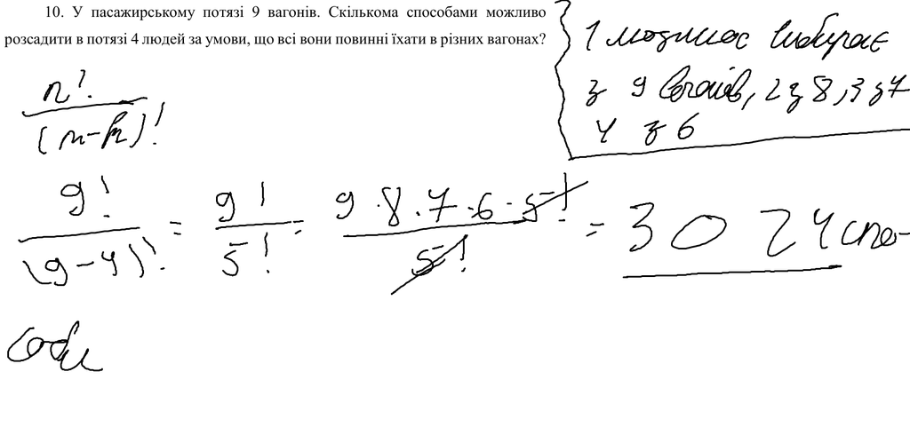

# 4 . На колі вибрано 10 точок. а) скільки можливо провести хорд з кінцями в цих точках? б) скільки існує трикутників з вершинами в цих точках?

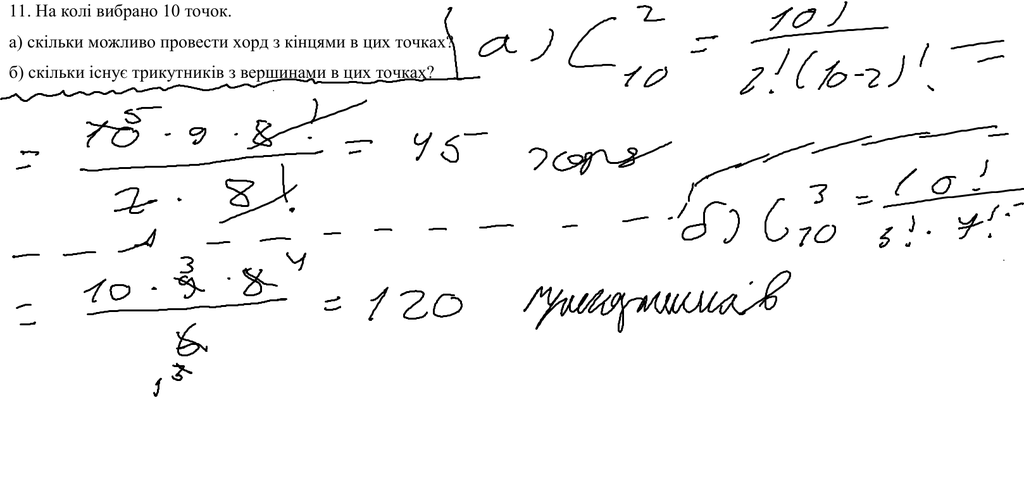

# 5 . Доведіть тотожність

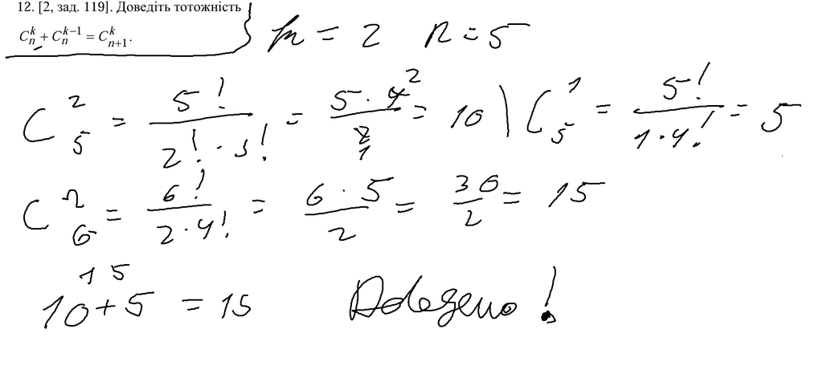

# 6 . Контрольні питання.

- Що вивчає комбінаторика? - Комбінаторика вивчає способи вибору, розміщення та впорядкування елементів з деякої множини. Вона зосереджена на підрахунку можливих комбінацій, перестановок і розміщень, які можна утворити з цих елементів, керуючись певними правилами.
- Що таке класична урнова схема і яке значення вона має для комбінаторики? - Це модель для ілюстрації комбінаторних задач , за її допомогою можна легко візуалізувати складніші концепції, такі як вибірка з поверненням і без повернення.Має велике значення для комбінаторика так як є легкою для уявлення та візуалізаціїї та за її допомогою можна легко вирішувати задачі.
- Що таке перестановка і як знаходити їхню кількість для заданої множини елементів? - Перестановка це будь-яка впорядкована множина, що складається з усіх елементів даної скінченної множини.Щоб знайти кількість перестановки для заданох множини елементів застосовуєть формула n! (якщо задача без додаткових умов).
- Яка кількість розміщень можлива для 𝑘 елементів у множині з 𝑛 елементів? - Без повернення n!/(n-k)!.
- Як визначити кількість способів вибору 𝑘 елементів із множини, де порядок не має значення? - Без повернення n!/(k!*(n-k)!).

# 3 . Висновки

На цьому практичному занятті ми набули практичних навичок у розв'язанні задач з комбінаторик , взнали що вивчає комбінаторик та що таке класична урнова схема.